# PMIM402J Classification

Student no. 2005070

2024-07-24

## Libraries and setup

```r
library(tidyverse) # For code syntax
library(mice) # For imputation
library(pROC) # For roc() and ggroc()
library(randomForest) # For random forest analysis
library(DataExplorer) # For plot_correlation()
library(gtsummary) # For tbl_regression()
seed <- 50
set.seed(seed)
```

## Data preparation and preprocessing

**Q1a. Did you undertake any preprocessing? If so, why?**

Preprocessing for both classifiers was undertaken after viewing a summary of the original data. The pacemaker variable was removed as it only consisted of one level and therefore would not have been useful in classification. The X variable was also removed as the numbers were random and unnecessary. The drug variable was recoded so that “none” was replaced by 0, “aspirin” or “clopidogrel” were replaced by 1, and “both” was replaced by 2, indicating the number of prescribed cardiovascular drugs. The family history variable was also recoded so that “no” was replaced by 0 and “yes” was replaced by 1. This recoding was necessary so that the data was in a suitable form for classification analysis. Histograms were then plotted which revealed that the cholesterol, maximum heart rate and resting blood pressure variables (‘chol’, ‘thalach’ and ‘trestbps’ respectively) had multiple ‘0’ values which would not be possible. As such, these values were replaced by NAs and suitable values were imputed using MICE. However, the ‘chol’ variable was then removed as over 20% of the data had been missing. A summary of the data was viewed again to check that the imputed data looked normal. Finally, factor variables were formatted as such before the data was shuffled randomly and split into train (60%) and test (40%) data frames so that the machine learning models could be trained and tested using different data.

```r
# Loading the data and looking at it
data <- read.csv('heart_disease_modified.csv')
summary(data)
```

```
##        X           Patient_ID        sex              age
##  Min.   :  1.0   Min.   :  17   Min.   :0.0000   Min.   :28.00
##  1st Qu.:230.8   1st Qu.:2599   1st Qu.:1.0000   1st Qu.:47.00
##  Median :460.5   Median :4936   Median :1.0000   Median :54.00
##  Mean   :460.5   Mean   :4971   Mean   :0.7891   Mean   :53.51
##  3rd Qu.:690.2   3rd Qu.:7374   3rd Qu.:1.0000   3rd Qu.:60.00
##  Max.   :920.0   Max.   :9990   Max.   :1.0000   Max.   :77.00
##   pace_maker              cp          trestbps          chol
##  Length:920         Min.   :1.00   Min.   :  0.0   Min.   :  0.0
##  Class :character   1st Qu.:3.00   1st Qu.:120.0   1st Qu.:164.0
##  Mode  :character   Median :4.00   Median :130.0   Median :221.0
##                     Mean   :3.25   Mean   :123.7   Mean   :192.6
##                     3rd Qu.:4.00   3rd Qu.:140.0   3rd Qu.:267.0
##                     Max.   :4.00   Max.   :200.0   Max.   :603.0
##       fbs          restecg          thalach          exang
##  Min.   :0.00   Min.   :0.0000   Min.   :  0.0   Min.   :0.0000
##  1st Qu.:0.00   1st Qu.:0.0000   1st Qu.:115.0   1st Qu.:0.0000
##  Median :0.00   Median :0.0000   Median :138.0   Median :0.0000
##  Mean   :0.15   Mean   :0.6033   Mean   :129.3   Mean   :0.3663
##  3rd Qu.:0.00   3rd Qu.:1.0000   3rd Qu.:156.0   3rd Qu.:1.0000
##  Max.   :1.00   Max.   :2.0000   Max.   :202.0   Max.   :1.0000
##     oldpeak          perfusion           slope           ca
##  Min.   :-2.6000   Min.   :-0.9548   Min.   :1.0   Min.   :0.0000
##  1st Qu.: 0.0000   1st Qu.: 0.1902   1st Qu.:1.0   1st Qu.:0.0000
##  Median : 0.2000   Median : 0.5698   Median :2.0   Median :0.0000
##  Mean   : 0.8196   Mean   : 0.5533   Mean   :1.8   Mean   :0.2272
##  3rd Qu.: 1.5000   3rd Qu.: 0.8920   3rd Qu.:2.0   3rd Qu.:0.0000
##  Max.   : 6.2000   Max.   : 2.4143   Max.   :3.0   Max.   :3.0000
##       thal          smoker           drug              traponin
##  Min.   :3.00   Min.   :0.0000   Length:920         Min.   :-241.43
##  1st Qu.:3.00   1st Qu.:0.0000   Class :character   1st Qu.: -89.20
##  Median :6.00   Median :1.0000   Mode  :character   Median : -56.98
##  Mean   :5.32   Mean   :0.5163                      Mean   : -55.33
##  3rd Qu.:7.00   3rd Qu.:1.0000                      3rd Qu.: -19.02
##  Max.   :7.00   Max.   :1.0000                      Max.   :  95.48
##    fam_hist             class
##  Length:920         Min.   :0.0000
##  Class :character   1st Qu.:0.0000
##  Mode  :character   Median :1.0000
##                     Mean   :0.5533
##                     3rd Qu.:1.0000
##                     Max.   :1.0000
```

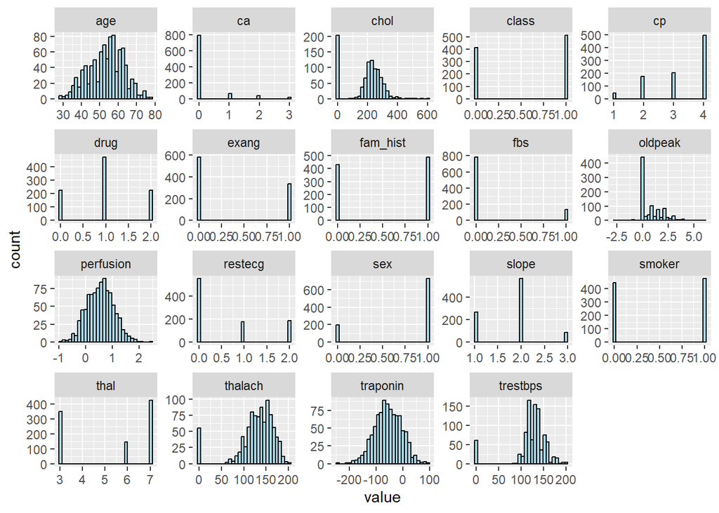

```r
# Removing unnecessary variables
data <- data %>% select(-X, -pace_maker, -Patient_ID)

# Recoding character variables into numeric
data$drug <- recode(data$drug,
                    "None" = 0, "Aspirin" = 1, "Clopidogrel" = 1, "Both" = 2)

data$fam_hist <- recode(data$fam_hist, "no" = 0, "yes" = 1)

# Looking at the data using histograms
data %>% gather(attributes, value, 1:ncol(data)) %>%
  ggplot(aes(x = value)) +
  geom_histogram(fill = "lightblue", colour = "black") +
  facet_wrap(~attributes, scales = "free")
```

```r
# Showed lots of zeroes for variables chol, thalach & trestbps which we will convert to NAs
data <- data %>% mutate(chol = ifelse(chol == 0, NA, chol),
                        thalach = ifelse(thalach == 0, NA, thalach),
                        trestbps = ifelse(trestbps == 0, NA, trestbps))

# Percentage missing for each of the variables
data %>% filter(is.na(chol)) %>% nrow() / 920 * 100
```

```
## [1] 21.95652
```

```r
data %>% filter(is.na(thalach)) %>% nrow() / 920 * 100
```

```
## [1] 5.978261
```

```r
data %>% filter(is.na(trestbps)) %>% nrow() / 920 * 100
```

```
## [1] 6.521739
```

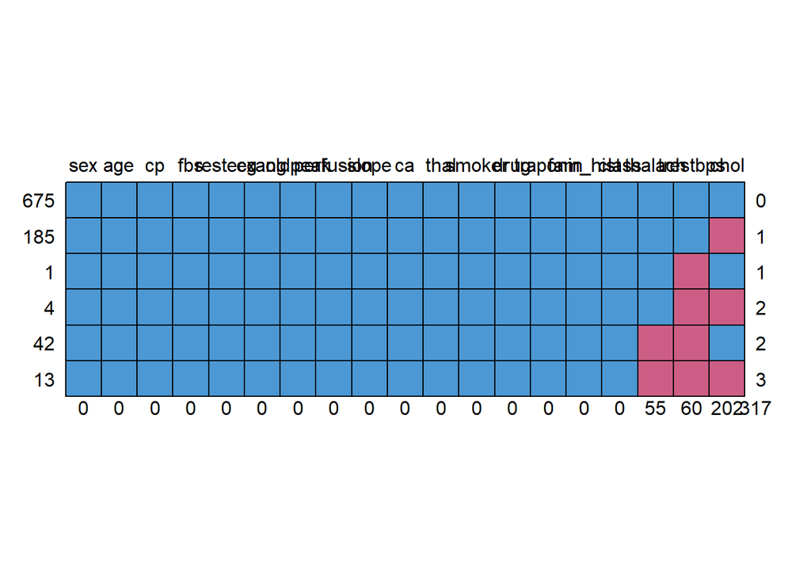

```
##     sex age cp fbs restecg exang oldpeak perfusion slope ca thal smoker drug
## 675   1   1  1   1       1     1       1         1     1  1    1      1    1
## 185   1   1  1   1       1     1       1         1     1  1    1      1    1
## 1     1   1  1   1       1     1       1         1     1  1    1      1    1
## 4     1   1  1   1       1     1       1         1     1  1    1      1    1
## 42    1   1  1   1       1     1       1         1     1  1    1      1    1
## 13    1   1  1   1       1     1       1         1     1  1    1      1    1
##       0   0  0   0       0     0       0         0     0  0    0      0    0
##     traponin fam_hist class thalach trestbps chol
## 675        1        1     1       1        1    1   0
## 185        1        1     1       1        1    0   1
## 1          1        1     1       1        0    1   1
## 4          1        1     1       1        0    0   2
## 42         1        1     1       0        0    1   2
## 13         1        1     1       0        0    0   3
##            0        0     0      55       60  202 317
```

```r
# Looking at the missing data
md.pattern(data)
```

```r
# Imputation
set.seed(seed)
imputedata <- data
imputedata <- mice(imputedata, m = 5, method= 'pmm')
imputedata <- complete(imputedata)
```

```r
# Checking the data looks okay after imputation
summary(imputedata)
```

```
##       sex              age              cp          trestbps
##  Min.   :0.0000   Min.   :28.00   Min.   :1.00   Min.   : 80.0
##  1st Qu.:1.0000   1st Qu.:47.00   1st Qu.:3.00   1st Qu.:120.0
##  Median :1.0000   Median :54.00   Median :4.00   Median :130.0
##  Mean   :0.7891   Mean   :53.51   Mean   :3.25   Mean   :132.4
##  3rd Qu.:1.0000   3rd Qu.:60.00   3rd Qu.:4.00   3rd Qu.:140.0
##  Max.   :1.0000   Max.   :77.00   Max.   :4.00   Max.   :200.0
##       chol            fbs          restecg          thalach
##  Min.   : 85.0   Min.   :0.00   Min.   :0.0000   Min.   : 60.0
##  1st Qu.:209.0   1st Qu.:0.00   1st Qu.:0.0000   1st Qu.:120.0
##  Median :240.0   Median :0.00   Median :0.0000   Median :140.0
##  Mean   :246.4   Mean   :0.15   Mean   :0.6033   Mean   :137.3
##  3rd Qu.:276.0   3rd Qu.:0.00   3rd Qu.:1.0000   3rd Qu.:156.2
##  Max.   :603.0   Max.   :1.00   Max.   :2.0000   Max.   :202.0
##      exang           oldpeak          perfusion           slope
##  Min.   :0.0000   Min.   :-2.6000   Min.   :-0.9548   Min.   :1.0
##  1st Qu.:0.0000   1st Qu.: 0.0000   1st Qu.: 0.1902   1st Qu.:1.0
##  Median :0.0000   Median : 0.2000   Median : 0.5698   Median :2.0
##  Mean   :0.3663   Mean   : 0.8196   Mean   : 0.5533   Mean   :1.8
##  3rd Qu.:1.0000   3rd Qu.: 1.5000   3rd Qu.: 0.8920   3rd Qu.:2.0
##  Max.   :1.0000   Max.   : 6.2000   Max.   : 2.4143   Max.   :3.0
##        ca              thal          smoker            drug
##  Min.   :0.0000   Min.   :3.00   Min.   :0.0000   Min.   :0.0000
##  1st Qu.:0.0000   1st Qu.:3.00   1st Qu.:0.0000   1st Qu.:1.0000
##  Median :0.0000   Median :6.00   Median :1.0000   Median :1.0000
##  Mean   :0.2272   Mean   :5.32   Mean   :0.5163   Mean   :0.9978
##  3rd Qu.:0.0000   3rd Qu.:7.00   3rd Qu.:1.0000   3rd Qu.:1.0000
##  Max.   :3.0000   Max.   :7.00   Max.   :1.0000   Max.   :2.0000
##     traponin          fam_hist          class
##  Min.   :-241.43   Min.   :0.0000   Min.   :0.0000
##  1st Qu.: -89.20   1st Qu.:0.0000   1st Qu.:0.0000
##  Median : -56.98   Median :1.0000   Median :1.0000
##  Mean   : -55.33   Mean   :0.5304   Mean   :0.5533
##  3rd Qu.: -19.02   3rd Qu.:1.0000   3rd Qu.:1.0000
##  Max.   :  95.48   Max.   :1.0000   Max.   :1.0000
```

```r
# And that there is no missing data now
md.pattern(imputedata)
```

```
##  /\     /\
## {  `---'  }
## {  O   O  }
## ==>  V <==  No need for mice. This data set is completely observed.
##  \  \|/  /
##   `-----'
```

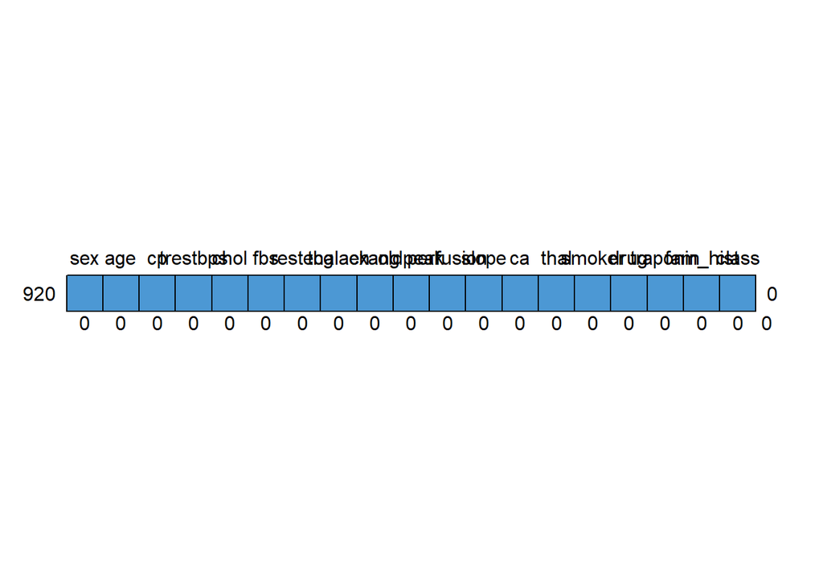

```
##     sex age cp trestbps chol fbs restecg thalach exang oldpeak perfusion slope
## 920   1   1  1        1    1   1       1       1     1       1         1     1
##       0   0  0        0    0   0       0       0     0       0         0     0
##     ca thal smoker drug traponin fam_hist class
## 920  1    1      1    1        1        1     1 0
##      0    0      0    0        0        0     0 0
```

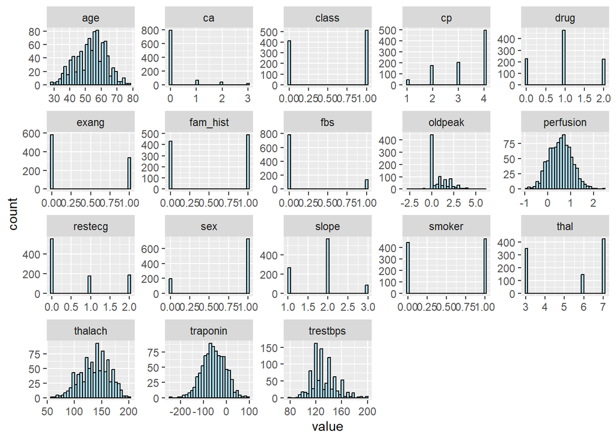

```r
# Removing cholesterol variable as there were too many NAs prior to imputation (>20%)
imputedata <- imputedata %>% select(-chol)

# Checking the data after imputation using histograms
imputedata %>% gather(attributes, value, 1:ncol(imputedata)) %>%
  ggplot(aes(x = value)) +
  geom_histogram(fill = "lightblue", colour = "black") +
  facet_wrap(~attributes, scales = "free")
```

```r
# Formatting factor variables
imputedata$sex <- as.factor(imputedata$sex)
imputedata$cp <- as.factor(imputedata$cp)
imputedata$fbs <- as.factor(imputedata$fbs)
imputedata$restecg <- as.factor(imputedata$restecg)
imputedata$exang <- as.factor(imputedata$exang)
imputedata$slope <- as.factor(imputedata$slope)
imputedata$thal <- as.factor(imputedata$thal)
imputedata$smoker <- as.factor(imputedata$smoker)
imputedata$drug <- as.factor(imputedata$drug)
imputedata$fam_hist <- as.factor(imputedata$fam_hist)

## Splitting into train and test data
set.seed(seed)
imputedata$class <- as.factor(imputedata$class)
bound <- (nrow(imputedata)/5)*3
imputedata <- imputedata[(sample(nrow(imputedata))),]
df.train <- imputedata[1:bound,]
df.test <- imputedata[(bound+1):nrow(imputedata),]
```

## Logistic regression

**Q1b. Run the classifier with default parameters.**

```r
# Training the regression model using training data
lr <- glm(class ~ ., family = "binomial", data = df.train)
lr
```

```
##
## Call:  glm(formula = class ~ ., family = "binomial", data = df.train)
##
## Coefficients:
## (Intercept)         sex1          age          cp2          cp3          cp4
##   -2.953056     0.890594     0.012863    -0.515651     0.752225     1.773741
##    trestbps         fbs1     restecg1     restecg2      thalach       exang1
##    0.007184     0.716732     0.349946     0.043625    -0.016051     1.097420
##     oldpeak    perfusion       slope2       slope3           ca        thal6
##    0.427378     0.142911     0.524451     0.103590     1.031458     1.393874
##       thal7      smoker1        drug1        drug2     traponin    fam_hist1
##    1.181992    -0.049449    -0.161786     0.253427           NA    -0.270062
##
## Degrees of Freedom: 551 Total (i.e. Null);  529 Residual
## Null Deviance:       760.7
## Residual Deviance: 406.6     AIC: 452.6
```

```r
# Results table
tbl_regression(lr, exponentiate = TRUE)
```

| **Characteristic** | **OR**<sup>1</sup> | **95% CI**<sup>1</sup> | **p-value** |
| --- | --- | --- | --- |
| sex |  |  |  |
| 0 | — | — |  |
| 1 | 2.44 | 1.27, 4.77 | 0.008 |
| age | 1.01 | 0.98, 1.05 | 0.4 |
| cp |  |  |  |
| 1 | — | — |  |
| 2 | 0.60 | 0.17, 2.11 | 0.4 |
| 3 | 2.12 | 0.70, 6.75 | 0.2 |
| 4 | 5.89 | 2.01, 18.3 | 0.002 |
| trestbps | 1.01 | 0.99, 1.02 | 0.4 |
| fbs |  |  |  |
| 0 | — | — |  |
| 1 | 2.05 | 0.92, 4.71 | 0.084 |
| restecg |  |  |  |
| 0 | — | — |  |
| 1 | 1.42 | 0.73, 2.80 | 0.3 |
| 2 | 1.04 | 0.52, 2.11 | >0.9 |
| thalach | 0.98 | 0.97, 1.00 | 0.009 |
| exang |  |  |  |
| 0 | — | — |  |
| 1 | 3.00 | 1.66, 5.49 | <0.001 |
| oldpeak | 1.53 | 1.16, 2.05 | 0.003 |
| perfusion | 1.15 | 0.67, 1.99 | 0.6 |
| slope |  |  |  |
| 1 | — | — |  |
| 2 | 1.69 | 0.90, 3.18 | 0.10 |
| 3 | 1.11 | 0.41, 3.05 | 0.8 |
| ca | 2.81 | 1.64, 5.14 | <0.001 |
| thal |  |  |  |
| 3 | — | — |  |
| 6 | 4.03 | 1.82, 9.17 | <0.001 |
| 7 | 3.26 | 1.84, 5.84 | <0.001 |
| smoker |  |  |  |
| 0 | — | — |  |
| 1 | 0.95 | 0.57, 1.57 | 0.8 |
| drug |  |  |  |
| 0 | — | — |  |
| 1 | 0.85 | 0.46, 1.58 | 0.6 |
| 2 | 1.29 | 0.59, 2.82 | 0.5 |
| traponin |  |  |  |
| fam_hist |  |  |  |
| 0 | — | — |  |
| 1 | 0.76 | 0.46, 1.26 | 0.3 |

<sup>1</sup> OR = Odds Ratio, CI = Confidence Interval

```r
# Applying the model to the test data
preds.lr <- predict(lr, df.test, type = "response")

# Creating a confusion matrix
cm.lr <- table(predicted = as.numeric(preds.lr>0.5), truth = df.test$class)
cm.lr
```

```
##          truth
## predicted   0   1
##         0 122  43
##         1  38 165
```

```r
# Checking accuracy
paste0("The accuracy is ", round(((cm.lr[1,1] + cm.lr[2,2]) / nrow(df.test)) * 100, 2), "%.")
```

```
## [1] "The accuracy is 77.99%."
```

```r
# Checking sensitivity
paste0("The sensitivity is ", round((cm.lr[2, 2] / (cm.lr[2, 2] + cm.lr[2, 1]) * 100), 2), "%.")
```

```
## [1] "The sensitivity is 81.28%."
```

```r
# Checking specificity
paste0("The specificity is ", round((cm.lr[1, 1] / (cm.lr[1, 1] + cm.lr[1, 2]) * 100), 2), "%.")
```

```
## [1] "The specificity is 73.94%."
```

**Q1c. How accurately can the classifier predict those that develop heart disease? What is in the output that signifies this?**

The overall accuracy of logistic regression was 77.99%. This was found by comparing the predicted outcomes with the true outcomes of the test data. By summing the correctly predicted negatives and correctly predicted positives, dividing by the total number of outcomes and multiplying by 100, we produce a percentage of the overall accuracy from correct predictions. So, ((122 + 165) / 368) * 100 = 77.99%. However, the sensitivity better informs one of how accurately the classifier predicts those that develop heart disease. Referring to values in the confusion matrix, the sensitivity can be calculated by dividing the number of correctly predicted true positives by the total number of predicted positives, and then multiplying by 100 to create a percentage. Therefore, the sensitivity is (165 / (165 + 38)) * 100 = 81.28%.

**Q1d. How many people are misclassified as developing heart disease? Where is this answer found in the output?**

38 people were misclassified as developing heart disease. This is the lower left number in the above confusion matrix, where individuals were predicted to have heart disease but in truth did not have heart disease.

**Q1e. Plot and submit ROC curves for the class that develops heart disease. What is another measure of accuracy commonly used?**

Another common measure of accuracy is the area under the ROC curve, known as the AUC. As with accuracy percentages, the higher the number the better. For logistic regression, the AUC was 0.86.

```r
# ROC analysis
res.lr <- roc(class ~ preds.lr, data = df.test)
res.lr$auc
```

```
## Area under the curve: 0.8602
```

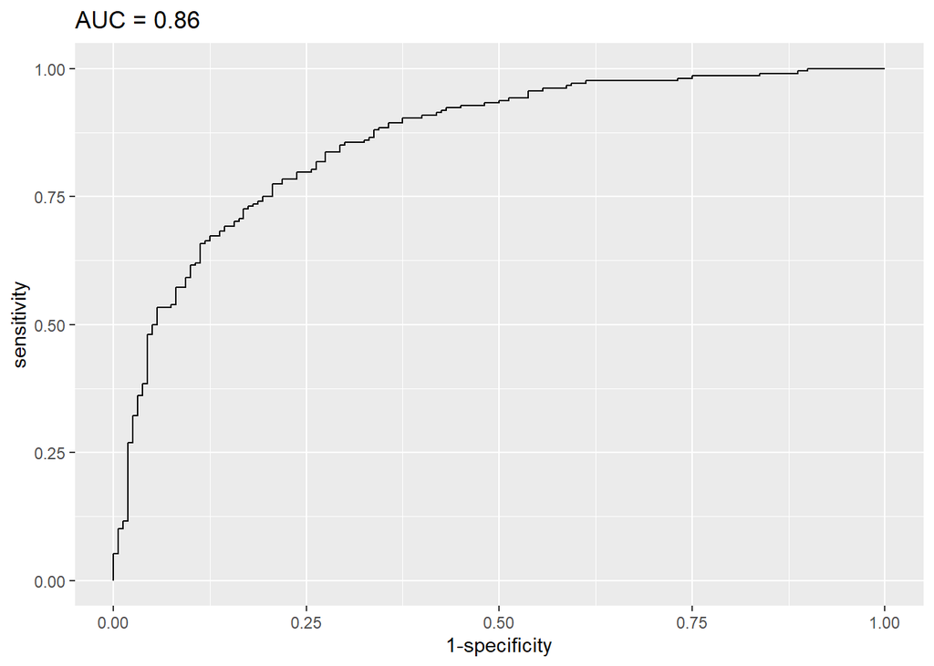

```r
ggroc(res.lr, legacy.axes = TRUE) +
  labs(title = paste0("AUC = ", round(res.lr$auc, 2)))
```

## Random forest

NB. Please refer to Q1a. above as the preprocessing was undertaken at once for both analyses.

**Q1b. Run the classifier with default parameters.**

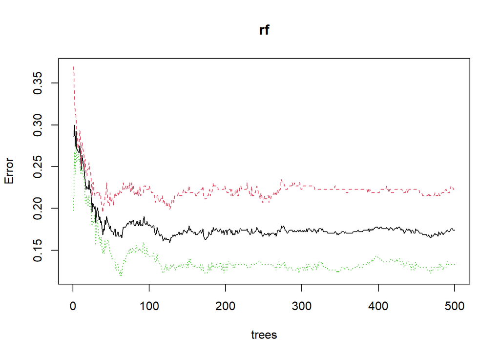

```r
# Training the model
set.seed(seed)
rf <- randomForest(class ~ ., data = df.train)
plot(rf) # Plotting the model
```

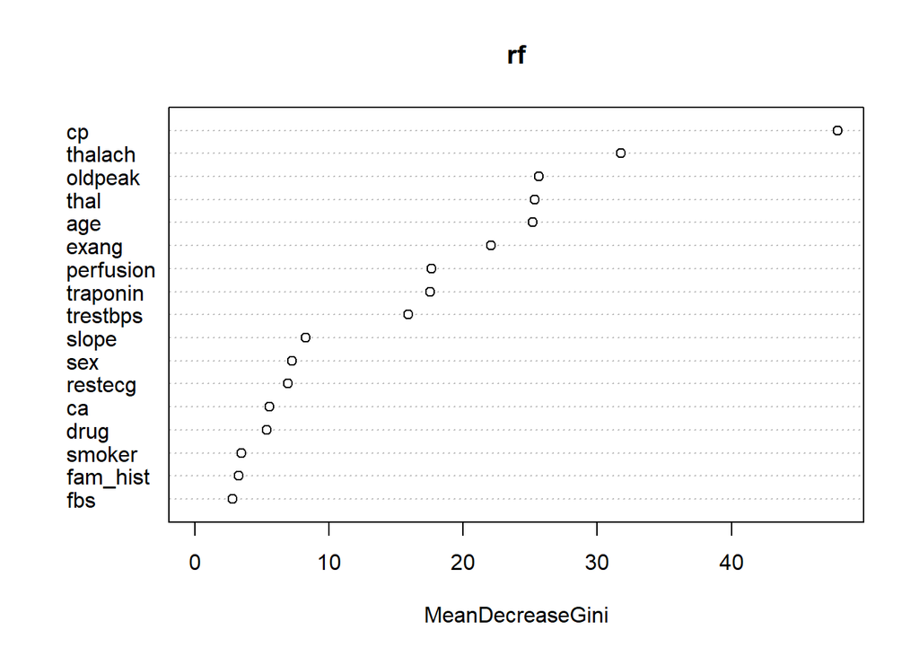

```r
varImpPlot(rf) # Plotting the variable importance
```

```r
# Applying the algorithm to the test data
preds.rf <- predict(rf, newdata = df.test, type = "response")

# Creating a confusion matrix
cm.rf <- table(predicted = preds.rf, truth = df.test$class)
cm.rf
```

```
##          truth
## predicted   0   1
##         0 120  37
##         1  40 171
```

```r
# Checking accuracy
paste0("The accuracy is ", round(((cm.rf[1,1] + cm.rf[2,2]) / nrow(df.test)) * 100, 2), "%.")
```

```
## [1] "The accuracy is 79.08%."
```

```r
# Checking sensitivity
paste0("The sensitivity is ", round((cm.rf[2, 2] / (cm.rf[2, 2] + cm.rf[2, 1]) * 100), 2), "%.")
```

```
## [1] "The sensitivity is 81.04%."
```

```r
# Checking specificity
paste0("The specificity is ", round((cm.rf[1, 1] / (cm.rf[1, 1] + cm.rf[1, 2]) * 100), 2), "%.")
```

```
## [1] "The specificity is 76.43%."
```

**Q1c. How accurately can the classifier predict those that develop heart disease? What is in the output that signifies this?**

The overall accuracy of the random forest was ((120 + 171) / 368) * 100 = 79.08%. However, the accuracy of predicting those that develop heart disease, i.e. the sensitivity, was (171 / (171 + 40)) * 100 = 81.04%. These values are drawn from the confusion matrix and the calculations are the same as were used for the logistic regression.

**Q1d. How many people are misclassified as developing heart disease? Where is this answer found in the output?**

40 people were misclassified as developing heart disease by random forest analysis. This is the lower left number in the above confusion matrix, where individuals were predicted to have heart disease but in truth did not have heart disease.

**Q1e. Plot and submit ROC curves for the class that develops heart disease. What is another measure of accuracy commonly used?**

Another measure of accuracy is the area under the ROC curve, known as the AUC. As with accuracy percentages, the higher the number the better. For random forest, the AUC was 0.79.

```r
# ROC analysis
res.rf <- roc(class ~ as.numeric(preds.rf), data = df.test)
res.rf$auc
```

```
## Area under the curve: 0.7861
```

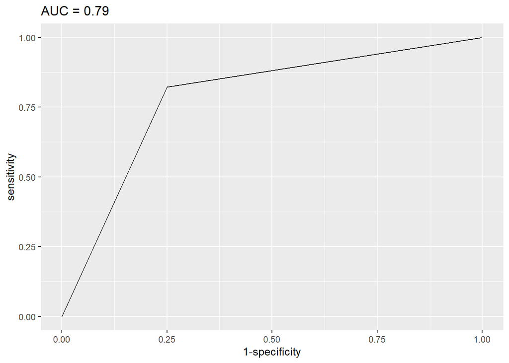

```r
ggroc(res.rf, legacy.axes = TRUE) +
  labs(title = paste0("AUC = ", round(res.rf$auc, 2)))
```

**Q2a. Why did you choose this classifier over the other?**

Random forest was chosen over logistic regression as it had a greater accuracy percentage but a lower AUC - it is of interest to increase both of these but particularly the AUC. In R, random forest has more internal hyperparameters to optimise than logistic regression which will also provide a greater opportunity to tune the model and improve its accuracy.

**Q2b. Explain how this classifier works from a theoretical point of view – try to include as much detail as possible.**

Random forest is a form of supervised machine learning, which means that the input data contains a classifier variable – the desired output value – to train the model to predict the class of other data. Random forest creates a ‘forest’ of many decision trees through a randomised process, hence its name.

To generate the many decision trees which make up the ‘forest’, the algorithm utilises bootstrapping and aggregation (collectively known as bagging). Bootstrapping involves the algorithm selecting a random sample of the dataset from which each decision tree is created. The trees also use a random subset of features when splitting, and as such each tree will be trained independently and a wide variation of individual results from the trees will be created. This bootstrapping and random feature selection process means that random forest models are less sensitive to the original training data which helps to avoid overfitting, reduces correlations between trees and improves generalisability – all of which enhance the accuracy of predictions.

Aggregation refers to the process through which the individual results of all decision trees are combined, and the model’s final output is determined through majority voting, i.e. if 60% of the trees predict the class to be ‘0’ and therefore 40% predict it to be ‘1’, the output will be class ‘0’. Due to this bagging process random forest is also referred to as an ‘ensemble’ learning method.

## Optimising random forest using feature selection

**Q2c. (i) Were there any features that could be removed?**

A correlation matrix of all variables was created, and it was found that troponin and perfusion had a strong negative correlation. However, removing troponin did not increase the accuracy of the model but instead decreased the accuracy, so it was decided these correlated variables would continue to be included. Next, a variable importance plot was created and the least important variables were dropped one by one. Removing ‘fbs’ first had a positive outcome, increasing the accuracy from 79.09% to 79.89%. However, removing the next variable ‘fam_hist’ decreased the accuracy to 79.35% (although still an improvement from the base model). It was decided that all variables except ‘fbs’ would be included in subsequent formulae.

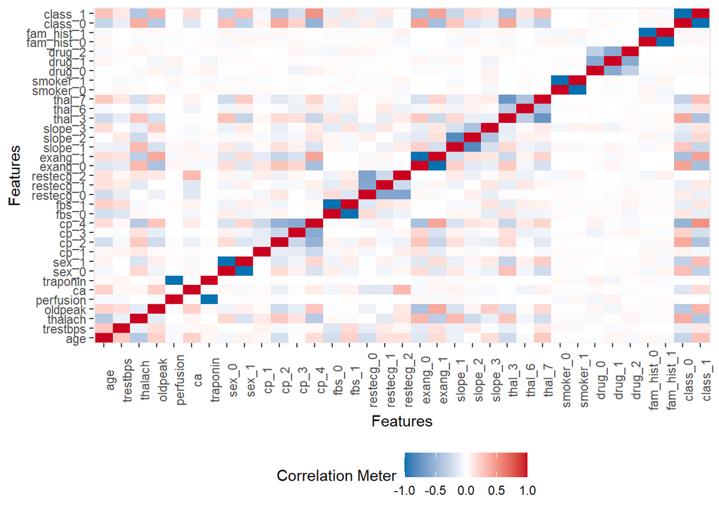

```r
# Plotting correlation matrix
plot_correlation(imputedata) # Troponin and perfusion are strongly correlated
```

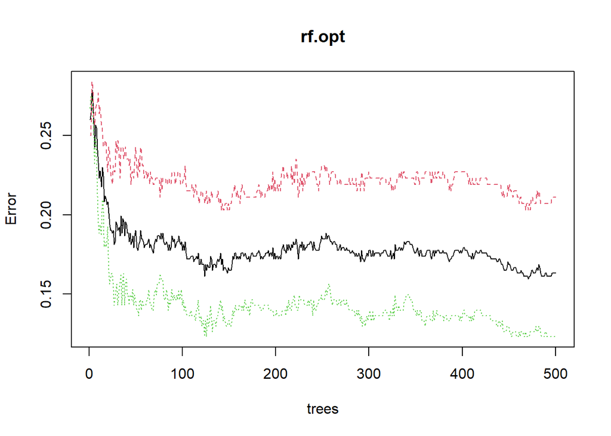

```r
# Training model without troponin
rf.opt <- randomForest(class ~ cp + thalach + thal + oldpeak + age + exang +
                         perfusion + trestbps + slope + sex + restecg + ca +
                         drug + smoker + fam_hist + fbs,
                       data = df.train)
plot(rf.opt)
```

```r
# Applying the algorithm to the test data
preds.opt <- predict(rf.opt, df.test, type = "response")

# Creating a confusion matrix
cm.opt <- table(predicted = preds.opt, truth = df.test$class)
cm.opt
```

```
##          truth
## predicted   0   1
##         0 119  37
##         1  41 171
```

```r
# Checking accuracy (decreased)
paste0("The accuracy is ", round(((cm.opt[1,1] + cm.opt[2,2]) / nrow(df.test)) * 100, 2), "%.")
```

```
## [1] "The accuracy is 78.8%."
```

```r
# Checking sensitivity
paste0("The sensitivity is ", round((cm.opt[2, 2] / (cm.opt[2, 2] + cm.opt[2, 1]) * 100), 2), "%.")
```

```
## [1] "The sensitivity is 80.66%."
```

```r
# Checking specificity
paste0("The specificity is ", round((cm.opt[1, 1] / (cm.opt[1, 1] + cm.opt[1, 2]) * 100), 2), "%." )
```

```
## [1] "The specificity is 76.28%."
```

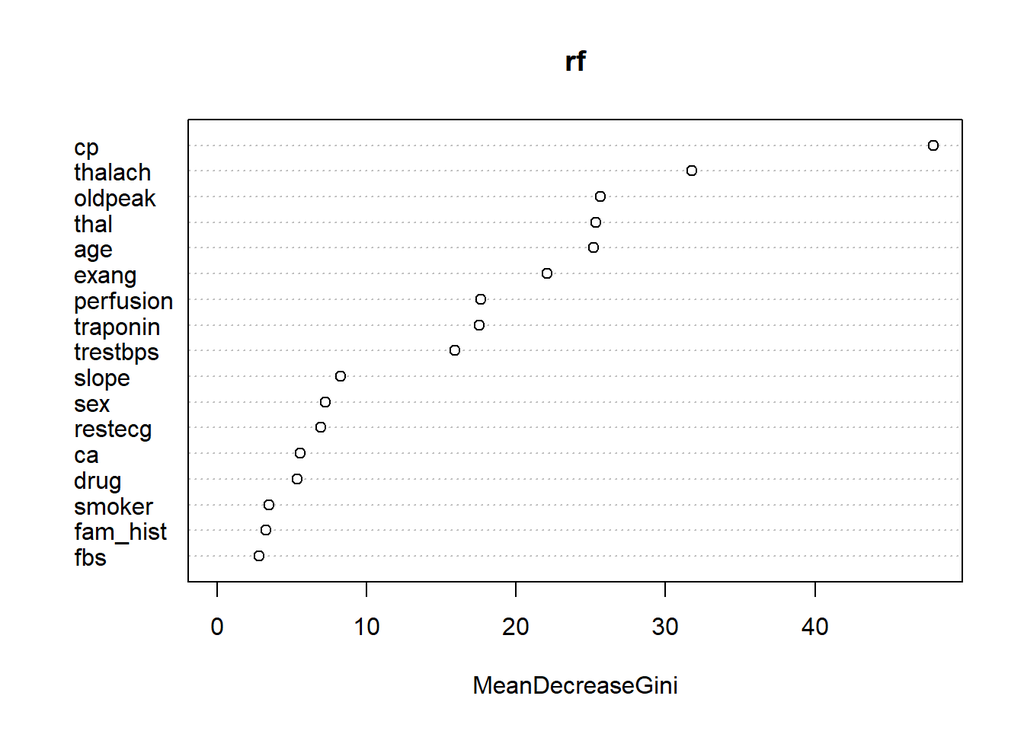

```r
# Since removing troponin did not help, we will try removing variables of least importance
varImpPlot(rf)
```

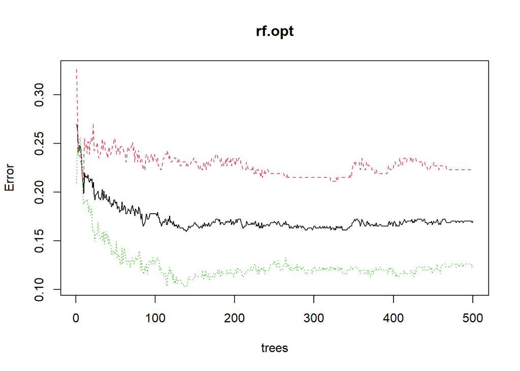

```r
# First removing the least important variable according to the plot: fbs
set.seed(seed)
rf.opt <- randomForest(class ~ cp + thalach + thal + oldpeak + age + exang +
                         perfusion + traponin + trestbps + slope + sex + restecg +
                         ca + drug + smoker + fam_hist,
                       data = df.train)
plot(rf.opt)
```

```r
# Applying the algorithm to the test data
preds.opt <- predict(rf.opt, df.test, type = "response")

# Creating a confusion matrix
cm.opt <- table(predicted = preds.opt, truth = df.test$class)
cm.opt
```

```
##          truth
## predicted   0   1
##         0 119  33
##         1  41 175
```

```r
# Checking accuracy (improved slightly this time)
round(((cm.opt[1,1] + cm.opt[2,2]) / nrow(df.test)) * 100, 2)  # accuracy
```

```
## [1] 79.89
```

```r
round((cm.opt[2, 2] / (cm.opt[2, 2] + cm.opt[2, 1]) * 100), 2) # sensitivity
```

```
## [1] 81.02
```

```r
round((cm.opt[1, 1] / (cm.opt[1, 1] + cm.opt[1, 2]) * 100), 2) # specificity
```

```
## [1] 78.29
```

```r
# ROC analysis
res.opt <- roc(class ~ as.numeric(preds.opt), data = df.test)
res.opt$auc
```

```
## Area under the curve: 0.7925
```

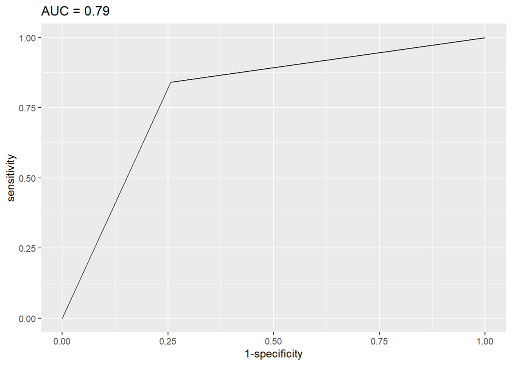

```r
ggroc(res.opt, legacy.axes = TRUE) +
  labs(title = paste0("AUC = ", round(res.opt$auc, 2)))
```

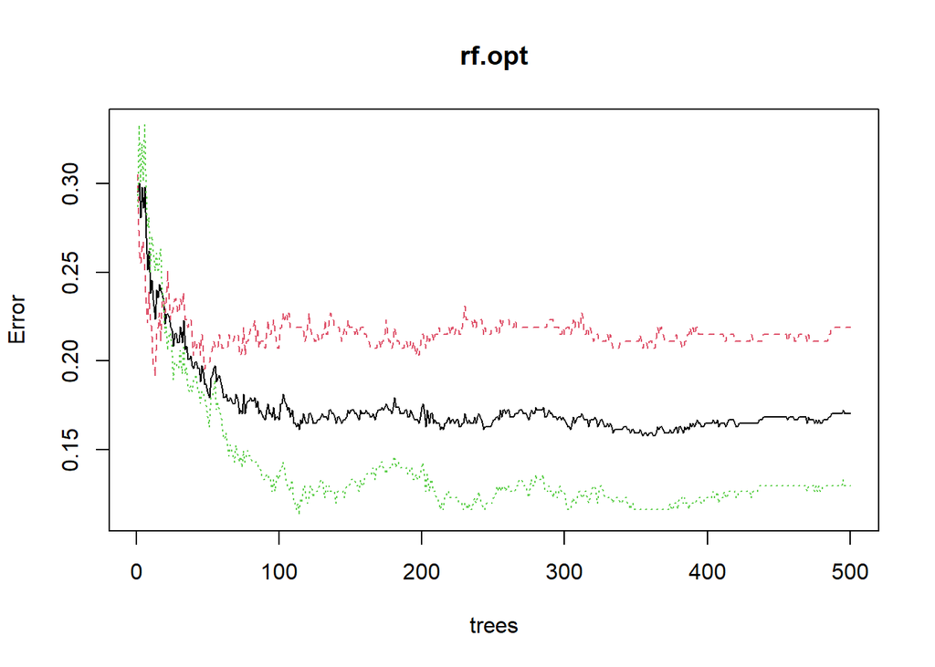

```r
# Repeating the analysis again, removing fam_hist this time

rf.opt <- randomForest(class ~ cp + thalach + thal + oldpeak + age + exang +
                         perfusion + traponin + trestbps + slope + sex + restecg +
                         ca + drug + smoker,
                       data = df.train)
plot(rf.opt)
```

```r
# Applying the algorithm to the test data
preds.opt <- predict(rf.opt, df.test, type = "response")

# Creating a confusion matrix
cm.opt <- table(predicted = preds.opt, truth = df.test$class)
cm.opt
```

```
##          truth
## predicted   0   1
##         0 119  35
##         1  41 173
```

```r
# Checking accuracy (it decreased this time so only fbs will be removed in future formulae)
round(((cm.opt[1,1] + cm.opt[2,2]) / nrow(df.test)) * 100, 2)  # accuracy
```

```
## [1] 79.35
```

```r
round((cm.opt[2, 2] / (cm.opt[2, 2] + cm.opt[2, 1]) * 100), 2) # sensitivity
```

```
## [1] 80.84
```

```r
round((cm.opt[1, 1] / (cm.opt[1, 1] + cm.opt[1, 2]) * 100), 2) # specificity
```

```
## [1] 77.27
```

```r
# ROC analysis
res.opt <- roc(class ~ as.numeric(preds.opt), data = df.test)
res.opt$auc
```

```
## Area under the curve: 0.7877
```

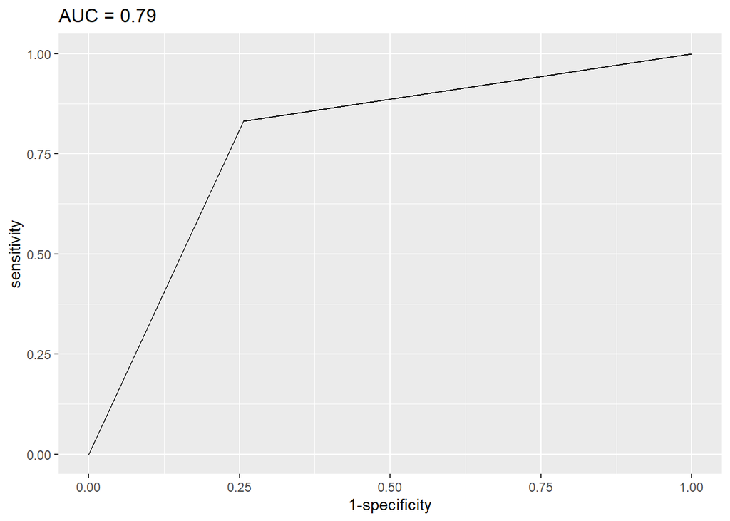

```r
ggroc(res.opt, legacy.axes = TRUE) +
  labs(title = paste0("AUC = ", round(res.opt$auc, 2)))
```